# Hierarchical Bayesian Analysis of Radon Data: An Enhanced Hamiltonian Monte Carlo Approach

### Running the Stan Sampler

We now run our Stan model using 4 chains with 2000 iterations each (1000 warmup iterations and 1000 sampling iterations):

```r
fit <- stan(file = "radon_model.stan",
            data = radon_data,
            iter = 2000,
            warmup = 1000,
            chains = 4,
            seed = 123)
```

Summary of the posterior distributions for the key parameters:

```r
print(fit, pars = c("beta", "mu_alpha", "tau", "sigma"), probs = c(0.025, 0.5, 0.975))
Inference for Stan model: anon_model.
4 chains, each with iter=2000; warmup=1000; thin=1;
post-warmup draws per chain=1000, total post-warmup draws=4000.

          mean se_mean   sd  2.5%   50% 97.5% n_eff Rhat
beta     -0.66       0 0.07 -0.79 -0.66 -0.54  8214    1
mu_alpha  1.49       0 0.05  1.39  1.49  1.60  2518    1
tau       0.32       0 0.05  0.24  0.32  0.42  1602    1
sigma     0.73       0 0.02  0.69  0.73  0.76  6996    1

Samples were drawn using NUTS(diag_e) at Mon Mar 24 04:13:56 2025.
For each parameter, n_eff is a crude measure of effective sample size,
and Rhat is the potential scale reduction factor on split chains (at
convergence, Rhat=1).
```

**Parameter Estimates:**

- $\beta$: The fixed effect for the floor variable has a mean of -0.66, with a 95% credible interval from -0.79 to -0.54. This negative value suggests that, all else being equal, measurements taken on an upper floor (assuming floor is coded as 1 for upper floor) are associated with lower log radon levels compared to basement measurements.
- $\mu_\alpha$: The overall (global) intercept is estimated at 1.49, with a credible interval from 1.39 to 1.60. This represents the average log radon level for the baseline (reference) group.
- $\tau$: The between-county standard deviation is estimated at 0.32 (credible interval: 0.24 to 0.42), quantifying the variability in county-specific intercepts.
- $\sigma$: The residual standard deviation (within-county variability) is estimated at 0.73 (credible interval: 0.69 to 0.76).

### Diagnostic Checks

After sampling, it is important to check that the chains have converged and that the posterior exploration is adequate. We use several diagnostic tools available in the bayesplot package.

#### Trace Plots

Trace plots provide to us a visual representation of the sampling paths across chains. We expect that well-mixed chains should appear as overlapping, horizontal “fuzzy caterpillars.”

We convert the fitted model to an array for bayesplot and investigate the traces:

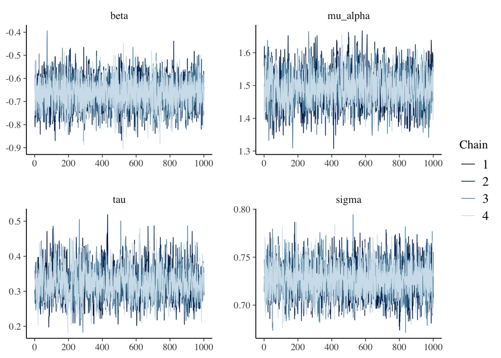

```r
posterior_samples <- as.array(fit)
mcmc_trace(posterior_samples, pars = c("beta", "mu_alpha", "tau", "sigma"))
```

From these trace plots, we see that all four chains appear to have converged and are mixing well. Each chain fluctuates around a similar central value for each parameter, and we observe no pronounced upward or downward trends. The overlap among chains is substantial, suggesting that we have reached a stable sampling distribution. We also see no abrupt jumps or signs of poor mixing, which reinforces that our NUTS sampler is exploring the posterior efficiently.

#### Pair Plots

Pair plots help us assess potential correlations between parameters and they also provide an overview of the joint posterior distributions.

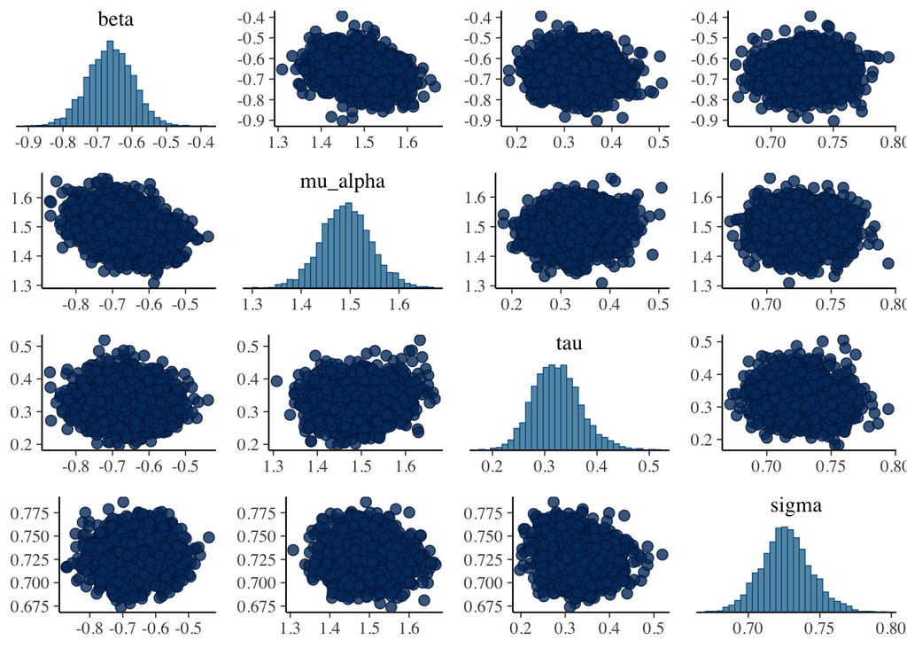

```r
mcmc_pairs(posterior_samples, pars = c("beta", "mu_alpha", "tau", "sigma"))
```

**Marginal Distributions (Diagonals):**

Each parameter’s histogram is roughly unimodal and does not exhibit strong skew or multiple modes. This suggests that the posterior for each parameter is relatively stable and well-identified.

**Pairwise Relationships (Off-Diagonals):**

The scatter plots show how each parameter’s posterior samples relate to the others. We do not see strong linear or nonlinear patterns, indicating that no pair of parameters is highly correlated. This relative lack of strong correlation is a good sign for efficient sampling and clear parameter interpretation.

**Overall Posterior Behavior:**

The tight, roughly elliptical scatter clouds in the off-diagonal plots, combined with unimodal marginals, suggest that our model converged well and that the parameters are well estimated. There is no visual evidence of pathological behavior such as multi-modality or heavy tail correlations that could impede inference.

### Convergence Statistics

In this subsection, we demonstrate several methods we have learned for assessing convergence of our Markov chains. By confirming that our sampler has stabilized around the same region across chains, exhibits minimal autocorrelation, and has sufficiently large effective sample sizes, we gain confidence that the posterior draws are reliable.

#### Multiple Chains and R-hat

We ran multiple Markov chains in parallel. When each chain converges to the same region of parameter space, it provides evidence that the sampler is exploring the true posterior rather than getting stuck in a local mode. In Stan’s output, the $\hat{R}$ statistic quantifies the potential scale reduction factor.

```r
rhat_values <- rhat(fit, pars = c("beta", "mu_alpha", "tau", "sigma"))
print(rhat_values)
     beta  mu_alpha       tau     sigma
0.9991654 1.0000166 0.9994363 0.9995218
```

An $\hat{R}$ value of 1 indicates perfect convergence, meaning that the variability between the chains is nearly identical to the variability within each chain. Typically, values below 1.1 are considered acceptable, so our values confirm that our chains have converged well. This gives us confidence that the posterior estimates are reliable and that our sampler has thoroughly explored the target distribution.

#### Effective Sample Size (ESS)

The effective sample size (ESS) measures how many nearly independent draws we have relative to the total samples. High autocorrelation within a chain reduces the ESS. Stan reports both an absolute ESS and an ESS ratio. A higher ESS indicates more information for reliable posterior estimation.

```r
ess_values <- neff_ratio(fit, pars = c("beta", "mu_alpha", "tau", "sigma"))
print(ess_values)
     beta  mu_alpha       tau     sigma
2.0536017 0.6295198 0.4005874 1.7488881
```

The ESS ratio for $\beta$ (2.05) and $\sigma$ (1.75) indicate that these parameters are sampled with high efficiency — i.e., the chains for these parameters have relatively low autocorrelation. On the other hand, $\mu_\alpha$ (0.63) and $\tau$ (0.40) have lower ESS ratios, suggesting that their chains exhibit higher autocorrelation and thus provide fewer independent draws. Although these lower ratios might still be acceptable, they indicate that further tuning or additional iterations could be beneficial to improve the precision of our estimates for these parameters.